# EX5 Visualization_19BCE1180

## NAME: AVIREDDY NVSRK ROHAN

##REG.NO: 19BCE1180 Use the newsurvey data obtained by cleaning ‘na’ values in survey data of MASS package to do the following:

```r
library(dplyr)
```

```r
library(graphics)
```

```r
library(MASS)
data("survey")
newsurvey <- na.omit(survey)
str(newsurvey)
```

```
## 'data.frame':    168 obs. of  12 variables:
##  $ Sex   : Factor w/ 2 levels "Female","Male": 1 2 2 1 2 1 2 2 1 1 ...
##  $ Wr.Hnd: num  18.5 19.5 20 18 17.7 17 20 18.5 17 19.5 ...
##  $ NW.Hnd: num  18 20.5 20 17.7 17.7 17.3 19.5 18.5 17.2 20.2 ...
##  $ W.Hnd : Factor w/ 2 levels "Left","Right": 2 1 2 2 2 2 2 2 2 2 ...
##  $ Fold  : Factor w/ 3 levels "L on R","Neither",..: 3 3 2 1 1 3 3 3 1 1 ...
##  $ Pulse : int  92 104 35 64 83 74 72 90 80 66 ...
##  $ Clap  : Factor w/ 3 levels "Left","Neither",..: 1 1 3 3 3 3 3 3 3 2 ...
##  $ Exer  : Factor w/ 3 levels "Freq","None",..: 3 2 3 3 1 1 3 3 1 3 ...
##  $ Smoke : Factor w/ 4 levels "Heavy","Never",..: 2 4 2 2 2 2 2 2 2 2 ...
##  $ Height: num  173 178 165 173 183 ...
##  $ M.I   : Factor w/ 2 levels "Imperial","Metric": 2 1 2 1 1 2 2 2 1 2 ...
##  $ Age   : num  18.2 17.6 23.7 21 18.8 ...
##  - attr(*, "na.action")= 'omit' Named int [1:69] 3 4 12 13 15 16 19 25 26 29 ...
##   ..- attr(*, "names")= chr [1:69] "3" "4" "12" "13" ...
```

QUESTIONS: 1. Plot a bar graph for the number of male and female participants in the survey. Provide the title as “Male and Female participants”, y-axis label as “frequency” and specify the colours for the bars.

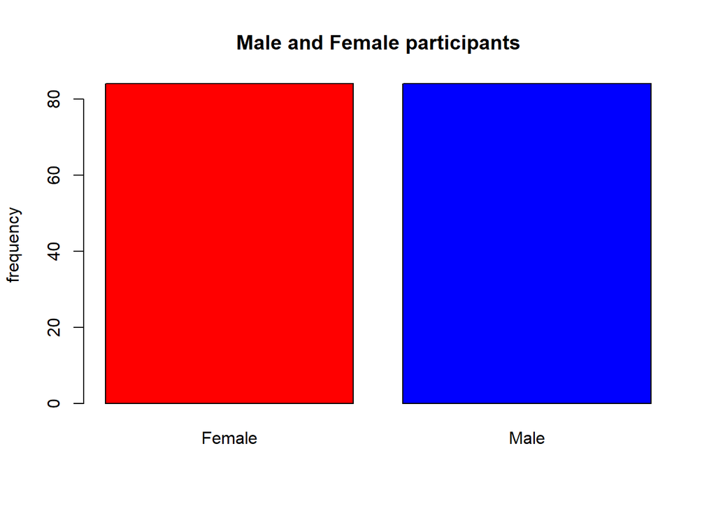

```r
gen_freq <- table(newsurvey$Sex)
barplot(gen_freq,col=c("red","blue"),main="Male and Female participants",ylab="frequency")
```

2. Plot a bar graph for the number of left handers and right handers in the survey. Provide the title as “Left Handers and Right Handers”, y-axis label as “count” and specify the colours for the bars.

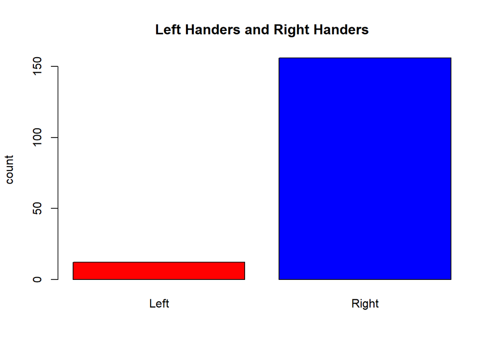

```r
hand_freq <- table(newsurvey$W.Hnd)
barplot(hand_freq,col=c("red","blue"),main="Left Handers and Right Handers",ylab="count")
```

3. Plot the distribution between male right handers and female right handers using bar chart. Provide the title as “Female Right Handers and Male Right Handers , y-axis label as “count” and specify the colours for the bars.

[figure not shown]

```r
gen_right <- newsurvey%>%
                filter(W.Hnd=="Right")%>%
                dplyr::select(Sex,W.Hnd)
gen_right <- table(gen_right$Sex)
barplot(hand_freq,col=c("red","blue"),main="Female Right Handers and Male Right Handers",ylab="count")
```

4. Draw the distribution of smoking habits of male right handers using pie chart.

[figure not shown]

```r
smoke_male <- newsurvey%>%
                filter(Sex=="Male",W.Hnd=="Right")%>%
                dplyr::select(Smoke)
smoke_male <- table(smoke_male)

pie(smoke_male,labels=c("Never","Regul", "Heavy", "Occas"),col = c("red","blue","green","yellow"))
```

5. Draw the histogram of age distribution with the title as ‘Age distribution’ and xlabel as ‘Age range’ and ylabel as ‘frequency’.

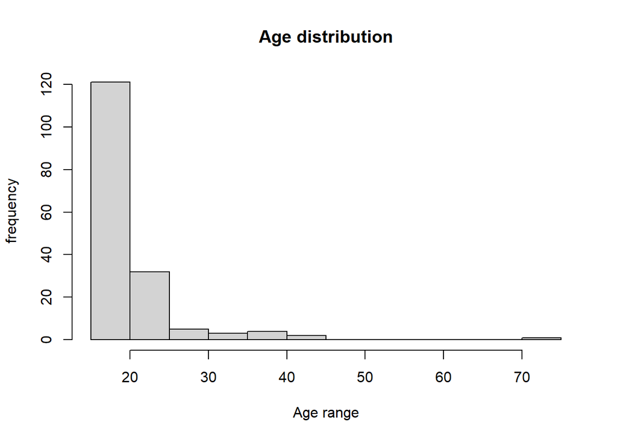

```r
hist(newsurvey$Age,xlab="Age range",ylab="frequency",main="Age distribution")
```

6. Reveal the relationship between the age and writing hand span using scatter plot.

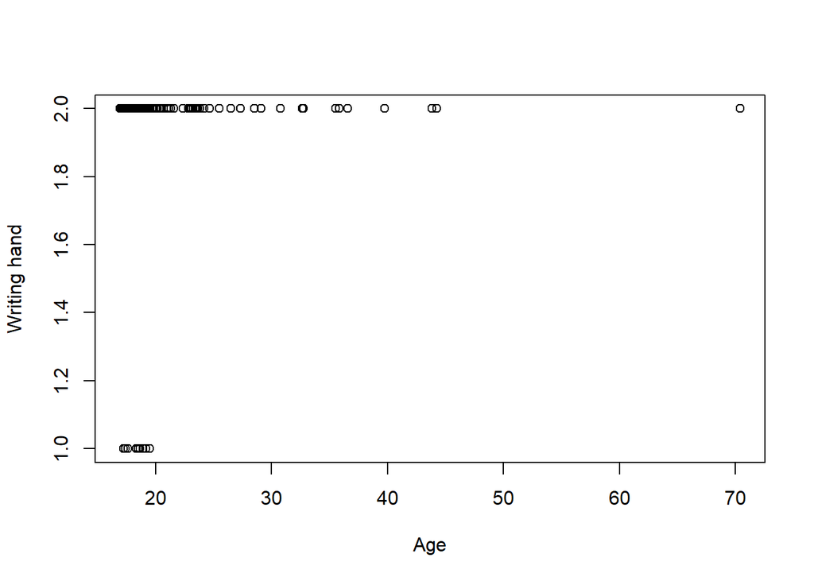

```r
plot(newsurvey$Age,newsurvey$W.Hnd,xlab="Age",ylab="Writing hand")
```

7. Draw the boxplot for pulse rate to analyse the five summary statistics. Provide appropriate title and label.

```r
summary(newsurvey$Pulse)
```

```
##    Min. 1st Qu.  Median    Mean 3rd Qu.    Max.
##   35.00   66.75   72.00   74.02   80.00  104.00
```

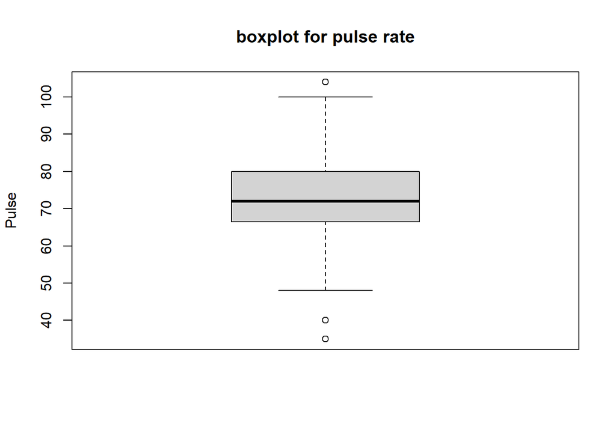

```r
boxplot(newsurvey$Pulse,main="boxplot for pulse rate",ylab="Pulse")
```

```r
house=read.csv("housing.csv")
house=na.omit(house)
house=sample_n(house,3000)
head(house)
```

```
##   longitude latitude housing_median_age total_rooms total_bedrooms population
## 1   -117.86    33.83                 23        2377            403       1101
## 2   -117.75    34.04                 22        2948            636       2600
## 3   -122.07    37.95                 39        2199            388       1025
## 4   -118.54    34.28                 18        5481            780       2477
## 5   -122.39    37.79                 52          94             24        113
## 6   -119.83    36.80                 24        3756            681       1586
##   households median_income median_house_value ocean_proximity
## 1        408        5.3439             227100       <1H OCEAN
## 2        602        3.1250             113600          INLAND
## 3        385        4.5893             190000        NEAR BAY
## 4        764        6.7248             377200       <1H OCEAN
## 5         27        4.6563             350000        NEAR BAY
## 6        739        3.8571              90100          INLAND
```

```r
str(house)
```

```
## 'data.frame':    3000 obs. of  10 variables:
##  $ longitude         : num  -118 -118 -122 -119 -122 ...
##  $ latitude          : num  33.8 34 38 34.3 37.8 ...
##  $ housing_median_age: num  23 22 39 18 52 24 37 6 17 29 ...
##  $ total_rooms       : num  2377 2948 2199 5481 94 ...
##  $ total_bedrooms    : num  403 636 388 780 24 ...
##  $ population        : num  1101 2600 1025 2477 113 ...
##  $ households        : num  408 602 385 764 27 739 242 952 936 283 ...
##  $ median_income     : num  5.34 3.12 4.59 6.72 4.66 ...
##  $ median_house_value: num  227100 113600 190000 377200 350000 ...
##  $ ocean_proximity   : chr  "<1H OCEAN" "INLAND" "NEAR BAY" "<1H OCEAN" ...
##  - attr(*, "na.action")= 'omit' Named int [1:207] 291 342 539 564 697 739 1098 1351 1457 1494 ...
##   ..- attr(*, "names")= chr [1:207] "291" "342" "539" "564" ...
```

```r
unique(house$ocean_proximity)
```

```
## [1] "<1H OCEAN"  "INLAND"     "NEAR BAY"   "NEAR OCEAN" "ISLAND"
```

8.Show the distribution in piechart for ocean_proximity for median_income>5

```r
temp <- house%>%
  filter(house$median_income>5)%>%
  dplyr::select(ocean_proximity)
temp=table(temp)
temp
```

```
## temp
##  <1H OCEAN     INLAND   NEAR BAY NEAR OCEAN
##        385        114        100         83
```

[figure not shown]

```r
pie(temp,labels=c("<1H OCEAN","NEAR OCEAN","INLAND","NEAR BAY" ,"ISLAND" ),col=c("red","blue","green","yellow","black","white"))
```

#INFERENCE for the above: AS WE CAN OBSERVE THAT PEOPLE WITH MEDIAN_INCOME GREATER THAN 50000 (represented as 5 value in thousands) prefer to be more closer to ocean

9.show the relationship between median income and median house price

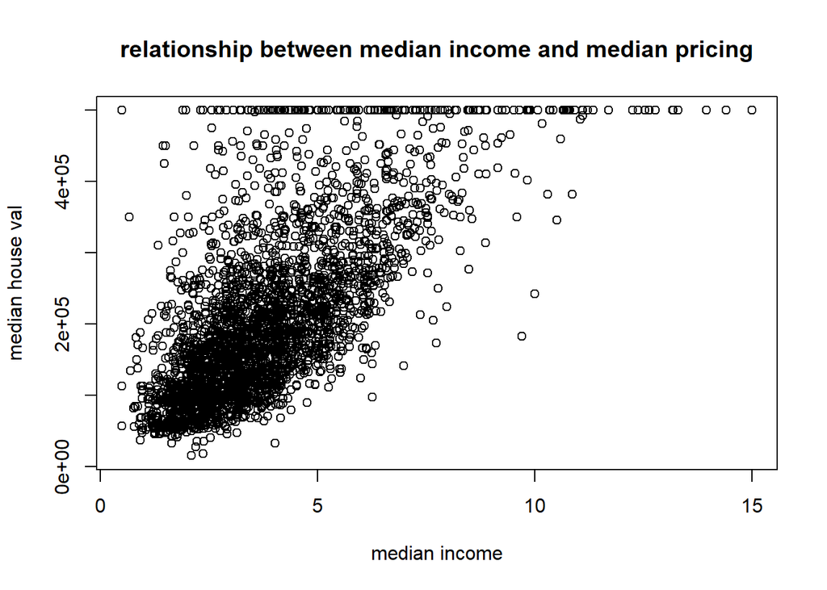

```r
plot(house$median_income,house$median_house_value,main="relationship between median income and median pricing",xlab="median income",ylab="median house val")
```

#INFERENCEfor the above: AS YOU CAN OBSERVE THERE IS A STRONG POSITIVE CORRELATION BETWEEN MEDIAN HOUSING VALUE AND MEDIAN INCOME

10.PROVIDE INFO ABOUT THE FREQUNECY DISTRIBUTION FOR HOUSES WITH THEIR MEDIAN AGE

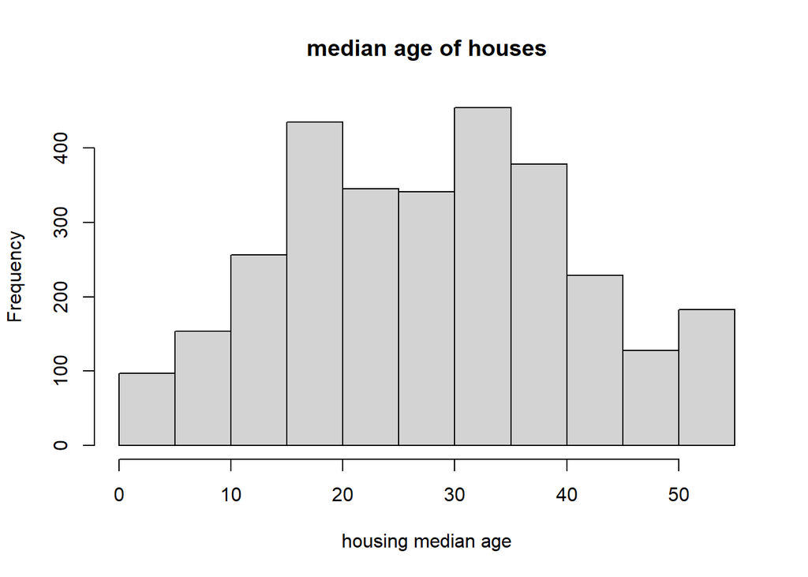

```r
hist(house$housing_median_age,xlab="housing median age",main="median age of houses")
```

#INFERENCE: from the plot we can infer that there are more houses whose age is between 30 to 40 yrs and less houses whose median age is less than 10 yrs